# Risk Factor Analysis

## Outcome Variable

**Outcome Variable:** ever_co

## Predictor Variables

**Intervention Variable:** earlybf

**Adjustment Set:**

- arm
- sex
- W_mage
- meducyrs
- feducyrs
- hhwealth_quart
- hfoodsec
- W_mhtcm
- W_mwtkg
- W_mbmi
- vagbrth
- W_gagebrth
- W_birthwt
- W_birthlen
- W_nrooms
- W_nchldlt5
- brthmon
- W_parity
- impfloor
- impsan
- safeh20
- delta_W_mage
- delta_meducyrs
- delta_feducyrs
- delta_hhwealth_quart
- delta_hfoodsec
- delta_W_mhtcm
- delta_W_mwtkg
- delta_W_mbmi
- delta_vagbrth
- delta_W_gagebrth
- delta_W_birthwt
- delta_W_birthlen
- delta_W_nrooms
- delta_W_nchldlt5
- delta_brthmon
- delta_W_parity
- delta_impfloor
- delta_impsan
- delta_safeh20

## Stratifying Variables

The analysis was stratified on these variable(s):

- agecat
- studyid
- country

## Data Summary

| agecat | studyid | country | earlybf | ever_co | n_cell | n |
| --- | --- | --- | --- | --- | --- | --- |
| 0-24 months | EE | PAKISTAN | 1 | 0 | 40 | 367 |
| 0-24 months | EE | PAKISTAN | 1 | 1 | 29 | 367 |
| 0-24 months | EE | PAKISTAN | 0 | 0 | 163 | 367 |
| 0-24 months | EE | PAKISTAN | 0 | 1 | 135 | 367 |
| 0-24 months | GMS-Nepal | NEPAL | 1 | 0 | 141 | 623 |
| 0-24 months | GMS-Nepal | NEPAL | 1 | 1 | 39 | 623 |
| 0-24 months | GMS-Nepal | NEPAL | 0 | 0 | 301 | 623 |
| 0-24 months | GMS-Nepal | NEPAL | 0 | 1 | 142 | 623 |
| 0-24 months | JiVitA-3 | BANGLADESH | 1 | 0 | 137 | 26843 |
| 0-24 months | JiVitA-3 | BANGLADESH | 1 | 1 | 29 | 26843 |
| 0-24 months | JiVitA-3 | BANGLADESH | 0 | 0 | 24316 | 26843 |
| 0-24 months | JiVitA-3 | BANGLADESH | 0 | 1 | 2361 | 26843 |
| 0-24 months | JiVitA-4 | BANGLADESH | 1 | 0 | 2898 | 5442 |
| 0-24 months | JiVitA-4 | BANGLADESH | 1 | 1 | 536 | 5442 |
| 0-24 months | JiVitA-4 | BANGLADESH | 0 | 0 | 1666 | 5442 |
| 0-24 months | JiVitA-4 | BANGLADESH | 0 | 1 | 342 | 5442 |
| 0-24 months | MAL-ED | BANGLADESH | 1 | 0 | 140 | 262 |
| 0-24 months | MAL-ED | BANGLADESH | 1 | 1 | 21 | 262 |
| 0-24 months | MAL-ED | BANGLADESH | 0 | 0 | 84 | 262 |
| 0-24 months | MAL-ED | BANGLADESH | 0 | 1 | 17 | 262 |
| 0-24 months | MAL-ED | BRAZIL | 1 | 0 | 107 | 233 |
| 0-24 months | MAL-ED | BRAZIL | 1 | 1 | 1 | 233 |
| 0-24 months | MAL-ED | BRAZIL | 0 | 0 | 123 | 233 |
| 0-24 months | MAL-ED | BRAZIL | 0 | 1 | 2 | 233 |
| 0-24 months | MAL-ED | INDIA | 1 | 0 | 115 | 250 |
| 0-24 months | MAL-ED | INDIA | 1 | 1 | 33 | 250 |
| 0-24 months | MAL-ED | INDIA | 0 | 0 | 81 | 250 |
| 0-24 months | MAL-ED | INDIA | 0 | 1 | 21 | 250 |
| 0-24 months | MAL-ED | NEPAL | 1 | 0 | 89 | 240 |
| 0-24 months | MAL-ED | NEPAL | 1 | 1 | 9 | 240 |

[output cut: 138 more lines]

The following strata were considered:

- agecat: 0-24 months, studyid: EE, country: PAKISTAN
- agecat: 0-24 months, studyid: GMS-Nepal, country: NEPAL
- agecat: 0-24 months, studyid: JiVitA-3, country: BANGLADESH
- agecat: 0-24 months, studyid: JiVitA-4, country: BANGLADESH
- agecat: 0-24 months, studyid: MAL-ED, country: BANGLADESH
- agecat: 0-24 months, studyid: MAL-ED, country: BRAZIL
- agecat: 0-24 months, studyid: MAL-ED, country: INDIA
- agecat: 0-24 months, studyid: MAL-ED, country: NEPAL
- agecat: 0-24 months, studyid: MAL-ED, country: PERU
- agecat: 0-24 months, studyid: MAL-ED, country: SOUTH AFRICA
- agecat: 0-24 months, studyid: MAL-ED, country: TANZANIA, UNITED REPUBLIC OF
- agecat: 0-24 months, studyid: NIH-Crypto, country: BANGLADESH
- agecat: 0-24 months, studyid: SAS-CompFeed, country: INDIA
- agecat: 0-24 months, studyid: ZVITAMBO, country: ZIMBABWE
- agecat: 0-6 months, studyid: EE, country: PAKISTAN
- agecat: 0-6 months, studyid: GMS-Nepal, country: NEPAL
- agecat: 0-6 months, studyid: JiVitA-3, country: BANGLADESH
- agecat: 0-6 months, studyid: JiVitA-4, country: BANGLADESH
- agecat: 0-6 months, studyid: MAL-ED, country: BANGLADESH
- agecat: 0-6 months, studyid: MAL-ED, country: BRAZIL
- agecat: 0-6 months, studyid: MAL-ED, country: INDIA
- agecat: 0-6 months, studyid: MAL-ED, country: NEPAL
- agecat: 0-6 months, studyid: MAL-ED, country: PERU
- agecat: 0-6 months, studyid: MAL-ED, country: SOUTH AFRICA
- agecat: 0-6 months, studyid: MAL-ED, country: TANZANIA, UNITED REPUBLIC OF
- agecat: 0-6 months, studyid: NIH-Crypto, country: BANGLADESH
- agecat: 0-6 months, studyid: SAS-CompFeed, country: INDIA
- agecat: 0-6 months, studyid: ZVITAMBO, country: ZIMBABWE
- agecat: 6-24 months, studyid: EE, country: PAKISTAN
- agecat: 6-24 months, studyid: GMS-Nepal, country: NEPAL
- agecat: 6-24 months, studyid: JiVitA-3, country: BANGLADESH
- agecat: 6-24 months, studyid: JiVitA-4, country: BANGLADESH
- agecat: 6-24 months, studyid: MAL-ED, country: BANGLADESH
- agecat: 6-24 months, studyid: MAL-ED, country: BRAZIL
- agecat: 6-24 months, studyid: MAL-ED, country: INDIA
- agecat: 6-24 months, studyid: MAL-ED, country: NEPAL
- agecat: 6-24 months, studyid: MAL-ED, country: PERU
- agecat: 6-24 months, studyid: MAL-ED, country: SOUTH AFRICA
- agecat: 6-24 months, studyid: MAL-ED, country: TANZANIA, UNITED REPUBLIC OF
- agecat: 6-24 months, studyid: NIH-Crypto, country: BANGLADESH
- agecat: 6-24 months, studyid: SAS-CompFeed, country: INDIA
- agecat: 6-24 months, studyid: ZVITAMBO, country: ZIMBABWE

### Dropped Strata

Some strata were dropped due to rare outcomes:

- agecat: 0-24 months, studyid: MAL-ED, country: BRAZIL
- agecat: 0-24 months, studyid: MAL-ED, country: PERU
- agecat: 0-24 months, studyid: MAL-ED, country: TANZANIA, UNITED REPUBLIC OF
- agecat: 0-6 months, studyid: MAL-ED, country: BANGLADESH
- agecat: 0-6 months, studyid: MAL-ED, country: BRAZIL
- agecat: 0-6 months, studyid: MAL-ED, country: NEPAL
- agecat: 0-6 months, studyid: MAL-ED, country: PERU
- agecat: 0-6 months, studyid: MAL-ED, country: SOUTH AFRICA
- agecat: 0-6 months, studyid: MAL-ED, country: TANZANIA, UNITED REPUBLIC OF
- agecat: 0-6 months, studyid: NIH-Crypto, country: BANGLADESH
- agecat: 6-24 months, studyid: JiVitA-3, country: BANGLADESH
- agecat: 6-24 months, studyid: MAL-ED, country: BRAZIL
- agecat: 6-24 months, studyid: MAL-ED, country: PERU
- agecat: 6-24 months, studyid: MAL-ED, country: TANZANIA, UNITED REPUBLIC OF
- agecat: 6-24 months, studyid: NIH-Crypto, country: BANGLADESH

## Methods Detail

We’re interested in the causal parameters $E[Y_a]$ for all values of $a \in \mathcal{A}$. These parameters represent the mean outcome if, possibly contrary to fact, we intervened to set all units to have $A=a$. Under the randomization and positivity assumptions, these are identified by the statistical parameters $\psi_a=E_W[E_{Y|A,W}(Y|A=a,W)]$. In addition, we’re interested in the mean of $Y$, $E[Y]$ under no intervention (the observed mean). We will estimate these parameters by using SuperLearner to fit the relevant likelihood factors – $E_{Y|A,W}(Y|A=a,W)$ and $p(A=a|W)$, and then updating our likelihood fit using a joint TMLE.

For unadjusted analyses ($W=\{\}$), initial likelihoods were estimated using Lrnr_glm to estimate the simple $E(Y|A)$ and Lrnr_mean to estimate $p(A)$. For adjusted analyses, a small library containing Lrnr_glmnet, Lrnr_xgboost, and Lrnr_mean was used.

Having estimated these parameters, we will then use the delta method to estimate relative risks and attributable risks relative to a prespecified baseline level of $A$.

# Results Detail

## Results Plots

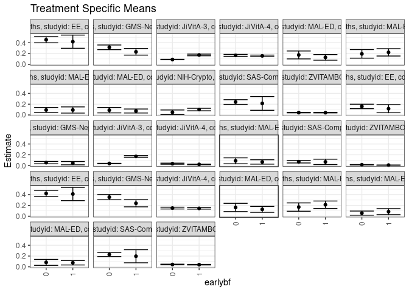

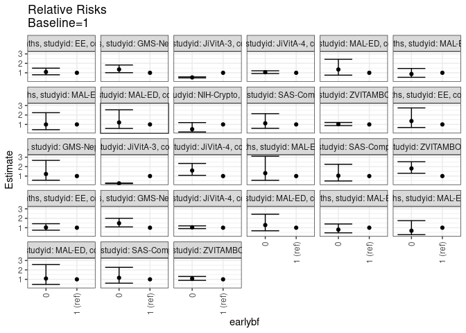

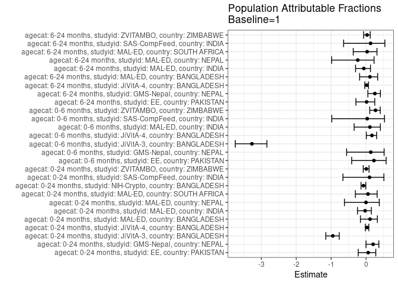

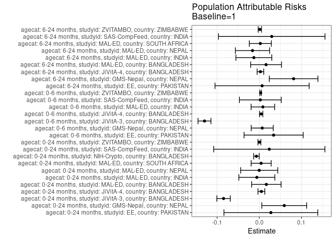

## Results Table

### Parameter: TSM

| agecat | studyid | country | intervention_level | baseline_level | estimate | ci_lower | ci_upper |
| --- | --- | --- | --- | --- | --- | --- | --- |
| 0-24 months | EE | PAKISTAN | 1 | NA | 0.4194080 | 0.2972059 | 0.5416100 |
| 0-24 months | EE | PAKISTAN | 0 | NA | 0.4550910 | 0.3985037 | 0.5116783 |
| 0-24 months | GMS-Nepal | NEPAL | 1 | NA | 0.2313651 | 0.1704278 | 0.2923024 |
| 0-24 months | GMS-Nepal | NEPAL | 0 | NA | 0.3146167 | 0.2715094 | 0.3577240 |
| 0-24 months | JiVitA-3 | BANGLADESH | 1 | NA | 0.1737191 | 0.1581912 | 0.1892471 |
| 0-24 months | JiVitA-3 | BANGLADESH | 0 | NA | 0.0885124 | 0.0844836 | 0.0925413 |
| 0-24 months | JiVitA-4 | BANGLADESH | 1 | NA | 0.1563381 | 0.1421954 | 0.1704809 |
| 0-24 months | JiVitA-4 | BANGLADESH | 0 | NA | 0.1657250 | 0.1480680 | 0.1833821 |
| 0-24 months | MAL-ED | BANGLADESH | 1 | NA | 0.1283665 | 0.0760838 | 0.1806493 |
| 0-24 months | MAL-ED | BANGLADESH | 0 | NA | 0.1733871 | 0.1002253 | 0.2465489 |
| 0-24 months | MAL-ED | INDIA | 1 | NA | 0.2217934 | 0.1540293 | 0.2895575 |
| 0-24 months | MAL-ED | INDIA | 0 | NA | 0.1935904 | 0.1141484 | 0.2730323 |
| 0-24 months | MAL-ED | NEPAL | 1 | NA | 0.0918367 | 0.0345397 | 0.1491337 |
| 0-24 months | MAL-ED | NEPAL | 0 | NA | 0.0915493 | 0.0440170 | 0.1390816 |
| 0-24 months | MAL-ED | SOUTH AFRICA | 1 | NA | 0.0730658 | 0.0358015 | 0.1103302 |
| 0-24 months | MAL-ED | SOUTH AFRICA | 0 | NA | 0.0881998 | 0.0383508 | 0.1380487 |
| 0-24 months | NIH-Crypto | BANGLADESH | 1 | NA | 0.1004566 | 0.0774553 | 0.1234579 |
| 0-24 months | NIH-Crypto | BANGLADESH | 0 | NA | 0.0495050 | 0.0071725 | 0.0918374 |
| 0-24 months | SAS-CompFeed | INDIA | 1 | NA | 0.2134435 | 0.0859481 | 0.3409389 |
| 0-24 months | SAS-CompFeed | INDIA | 0 | NA | 0.2391137 | 0.1955176 | 0.2827099 |
| 0-24 months | ZVITAMBO | ZIMBABWE | 1 | NA | 0.0421843 | 0.0372894 | 0.0470792 |
| 0-24 months | ZVITAMBO | ZIMBABWE | 0 | NA | 0.0433830 | 0.0382256 | 0.0485404 |
| 0-6 months | EE | PAKISTAN | 1 | NA | 0.1159420 | 0.0402976 | 0.1915864 |
| 0-6 months | EE | PAKISTAN | 0 | NA | 0.1577181 | 0.1162798 | 0.1991564 |
| 0-6 months | GMS-Nepal | NEPAL | 1 | NA | 0.0444444 | 0.0143146 | 0.0745743 |
| 0-6 months | GMS-Nepal | NEPAL | 0 | NA | 0.0541761 | 0.0330799 | 0.0752723 |
| 0-6 months | JiVitA-3 | BANGLADESH | 1 | NA | 0.1695852 | 0.1542697 | 0.1849007 |
| 0-6 months | JiVitA-3 | BANGLADESH | 0 | NA | 0.0389473 | 0.0363753 | 0.0415193 |
| 0-6 months | JiVitA-4 | BANGLADESH | 1 | NA | 0.0220307 | 0.0160063 | 0.0280552 |
| 0-6 months | JiVitA-4 | BANGLADESH | 0 | NA | 0.0349235 | 0.0247481 | 0.0450989 |
| 0-6 months | MAL-ED | INDIA | 1 | NA | 0.0675676 | 0.0270479 | 0.1080872 |
| 0-6 months | MAL-ED | INDIA | 0 | NA | 0.0882353 | 0.0330808 | 0.1433898 |
| 0-6 months | SAS-CompFeed | INDIA | 1 | NA | 0.0686275 | 0.0186437 | 0.1186112 |
| 0-6 months | SAS-CompFeed | INDIA | 0 | NA | 0.0712711 | 0.0481167 | 0.0944255 |
| 0-6 months | ZVITAMBO | ZIMBABWE | 1 | NA | 0.0085623 | 0.0063246 | 0.0107999 |
| 0-6 months | ZVITAMBO | ZIMBABWE | 0 | NA | 0.0154734 | 0.0122718 | 0.0186750 |
| 6-24 months | EE | PAKISTAN | 1 | NA | 0.4116277 | 0.2888337 | 0.5344216 |
| 6-24 months | EE | PAKISTAN | 0 | NA | 0.4217442 | 0.3649028 | 0.4785856 |
| 6-24 months | GMS-Nepal | NEPAL | 1 | NA | 0.2395764 | 0.1737631 | 0.3053897 |
| 6-24 months | GMS-Nepal | NEPAL | 0 | NA | 0.3531795 | 0.3050868 | 0.4012722 |
| 6-24 months | JiVitA-4 | BANGLADESH | 1 | NA | 0.1450670 | 0.1316123 | 0.1585216 |
| 6-24 months | JiVitA-4 | BANGLADESH | 0 | NA | 0.1505062 | 0.1338586 | 0.1671538 |
| 6-24 months | MAL-ED | BANGLADESH | 1 | NA | 0.1268888 | 0.0719947 | 0.1817829 |
| 6-24 months | MAL-ED | BANGLADESH | 0 | NA | 0.1623343 | 0.0856820 | 0.2389866 |
| 6-24 months | MAL-ED | INDIA | 1 | NA | 0.2128710 | 0.1440342 | 0.2817078 |
| 6-24 months | MAL-ED | INDIA | 0 | NA | 0.1694991 | 0.0921687 | 0.2468294 |
| 6-24 months | MAL-ED | NEPAL | 1 | NA | 0.0842105 | 0.0282485 | 0.1401725 |
| 6-24 months | MAL-ED | NEPAL | 0 | NA | 0.0571429 | 0.0186115 | 0.0956742 |
| 6-24 months | MAL-ED | SOUTH AFRICA | 1 | NA | 0.0759494 | 0.0345606 | 0.1173382 |
| 6-24 months | MAL-ED | SOUTH AFRICA | 0 | NA | 0.0824742 | 0.0276233 | 0.1373251 |
| 6-24 months | SAS-CompFeed | INDIA | 1 | NA | 0.1965839 | 0.0755385 | 0.3176293 |
| 6-24 months | SAS-CompFeed | INDIA | 0 | NA | 0.2285365 | 0.1901782 | 0.2668948 |
| 6-24 months | ZVITAMBO | ZIMBABWE | 1 | NA | 0.0401593 | 0.0347328 | 0.0455858 |
| 6-24 months | ZVITAMBO | ZIMBABWE | 0 | NA | 0.0432708 | 0.0371830 | 0.0493586 |

### Parameter: E(Y)

| agecat | studyid | country | intervention_level | baseline_level | estimate | ci_lower | ci_upper |
| --- | --- | --- | --- | --- | --- | --- | --- |
| 0-24 months | EE | PAKISTAN | NA | NA | 0.4468665 | 0.3959321 | 0.4978009 |
| 0-24 months | GMS-Nepal | NEPAL | NA | NA | 0.2905297 | 0.2548505 | 0.3262089 |
| 0-24 months | JiVitA-3 | BANGLADESH | NA | NA | 0.0890362 | 0.0851140 | 0.0929585 |
| 0-24 months | JiVitA-4 | BANGLADESH | NA | NA | 0.1613377 | 0.1500062 | 0.1726692 |
| 0-24 months | MAL-ED | BANGLADESH | NA | NA | 0.1450382 | 0.1023171 | 0.1877593 |
| 0-24 months | MAL-ED | INDIA | NA | NA | 0.2160000 | 0.1648868 | 0.2671132 |
| 0-24 months | MAL-ED | NEPAL | NA | NA | 0.0916667 | 0.0550838 | 0.1282495 |
| 0-24 months | MAL-ED | SOUTH AFRICA | NA | NA | 0.0774411 | 0.0469912 | 0.1078909 |
| 0-24 months | NIH-Crypto | BANGLADESH | NA | NA | 0.0936675 | 0.0729118 | 0.1144233 |
| 0-24 months | SAS-CompFeed | INDIA | NA | NA | 0.2370924 | 0.1969570 | 0.2772278 |
| 0-24 months | ZVITAMBO | ZIMBABWE | NA | NA | 0.0424623 | 0.0389147 | 0.0460100 |
| 0-6 months | EE | PAKISTAN | NA | NA | 0.1498638 | 0.1132959 | 0.1864317 |
| 0-6 months | GMS-Nepal | NEPAL | NA | NA | 0.0513644 | 0.0340170 | 0.0687117 |
| 0-6 months | JiVitA-3 | BANGLADESH | NA | NA | 0.0397202 | 0.0372135 | 0.0422270 |
| 0-6 months | JiVitA-4 | BANGLADESH | NA | NA | 0.0265122 | 0.0211694 | 0.0318550 |
| 0-6 months | MAL-ED | INDIA | NA | NA | 0.0760000 | 0.0430852 | 0.1089148 |
| 0-6 months | SAS-CompFeed | INDIA | NA | NA | 0.0710868 | 0.0489978 | 0.0931759 |
| 0-6 months | ZVITAMBO | ZIMBABWE | NA | NA | 0.0117638 | 0.0098602 | 0.0136673 |
| 6-24 months | EE | PAKISTAN | NA | NA | 0.4182825 | 0.3673274 | 0.4692377 |
| 6-24 months | GMS-Nepal | NEPAL | NA | NA | 0.3208955 | 0.2813387 | 0.3604523 |
| 6-24 months | JiVitA-4 | BANGLADESH | NA | NA | 0.1477252 | 0.1371297 | 0.1583206 |
| 6-24 months | MAL-ED | BANGLADESH | NA | NA | 0.1428571 | 0.0983068 | 0.1874075 |
| 6-24 months | MAL-ED | INDIA | NA | NA | 0.2000000 | 0.1487493 | 0.2512507 |
| 6-24 months | MAL-ED | NEPAL | NA | NA | 0.0680851 | 0.0358110 | 0.1003592 |
| 6-24 months | MAL-ED | SOUTH AFRICA | NA | NA | 0.0784314 | 0.0453685 | 0.1114942 |
| 6-24 months | SAS-CompFeed | INDIA | NA | NA | 0.2260619 | 0.1909133 | 0.2612105 |
| 6-24 months | ZVITAMBO | ZIMBABWE | NA | NA | 0.0413980 | 0.0374157 | 0.0453802 |

### Parameter: RR

| agecat | studyid | country | intervention_level | baseline_level | estimate | ci_lower | ci_upper |
| --- | --- | --- | --- | --- | --- | --- | --- |
| 0-24 months | EE | PAKISTAN | 1 | 1 | 1.0000000 | 1.0000000 | 1.0000000 |
| 0-24 months | EE | PAKISTAN | 0 | 1 | 1.0850796 | 0.7899800 | 1.4904146 |
| 0-24 months | GMS-Nepal | NEPAL | 1 | 1 | 1.0000000 | 1.0000000 | 1.0000000 |
| 0-24 months | GMS-Nepal | NEPAL | 0 | 1 | 1.3598274 | 1.0129363 | 1.8255153 |
| 0-24 months | JiVitA-3 | BANGLADESH | 1 | 1 | 1.0000000 | 1.0000000 | 1.0000000 |
| 0-24 months | JiVitA-3 | BANGLADESH | 0 | 1 | 0.5095147 | 0.4596970 | 0.5647310 |
| 0-24 months | JiVitA-4 | BANGLADESH | 1 | 1 | 1.0000000 | 1.0000000 | 1.0000000 |
| 0-24 months | JiVitA-4 | BANGLADESH | 0 | 1 | 1.0600425 | 0.9254740 | 1.2141778 |
| 0-24 months | MAL-ED | BANGLADESH | 1 | 1 | 1.0000000 | 1.0000000 | 1.0000000 |
| 0-24 months | MAL-ED | BANGLADESH | 0 | 1 | 1.3507186 | 0.7503118 | 2.4315767 |
| 0-24 months | MAL-ED | INDIA | 1 | 1 | 1.0000000 | 1.0000000 | 1.0000000 |
| 0-24 months | MAL-ED | INDIA | 0 | 1 | 0.8728408 | 0.5230134 | 1.4566567 |
| 0-24 months | MAL-ED | NEPAL | 1 | 1 | 1.0000000 | 1.0000000 | 1.0000000 |
| 0-24 months | MAL-ED | NEPAL | 0 | 1 | 0.9968701 | 0.4427226 | 2.2446334 |
| 0-24 months | MAL-ED | SOUTH AFRICA | 1 | 1 | 1.0000000 | 1.0000000 | 1.0000000 |
| 0-24 months | MAL-ED | SOUTH AFRICA | 0 | 1 | 1.2071276 | 0.5720898 | 2.5470773 |
| 0-24 months | NIH-Crypto | BANGLADESH | 1 | 1 | 1.0000000 | 1.0000000 | 1.0000000 |
| 0-24 months | NIH-Crypto | BANGLADESH | 0 | 1 | 0.4927993 | 0.2033366 | 1.1943305 |
| 0-24 months | SAS-CompFeed | INDIA | 1 | 1 | 1.0000000 | 1.0000000 | 1.0000000 |
| 0-24 months | SAS-CompFeed | INDIA | 0 | 1 | 1.1202673 | 0.5860422 | 2.1414820 |
| 0-24 months | ZVITAMBO | ZIMBABWE | 1 | 1 | 1.0000000 | 1.0000000 | 1.0000000 |
| 0-24 months | ZVITAMBO | ZIMBABWE | 0 | 1 | 1.0284163 | 0.8754399 | 1.2081242 |
| 0-6 months | EE | PAKISTAN | 1 | 1 | 1.0000000 | 1.0000000 | 1.0000000 |
| 0-6 months | EE | PAKISTAN | 0 | 1 | 1.3603188 | 0.6732560 | 2.7485342 |
| 0-6 months | GMS-Nepal | NEPAL | 1 | 1 | 1.0000000 | 1.0000000 | 1.0000000 |
| 0-6 months | GMS-Nepal | NEPAL | 0 | 1 | 1.2189616 | 0.5577744 | 2.6639218 |
| 0-6 months | JiVitA-3 | BANGLADESH | 1 | 1 | 1.0000000 | 1.0000000 | 1.0000000 |
| 0-6 months | JiVitA-3 | BANGLADESH | 0 | 1 | 0.2296620 | 0.2046268 | 0.2577602 |
| 0-6 months | JiVitA-4 | BANGLADESH | 1 | 1 | 1.0000000 | 1.0000000 | 1.0000000 |
| 0-6 months | JiVitA-4 | BANGLADESH | 0 | 1 | 1.5852172 | 1.0756441 | 2.3361942 |
| 0-6 months | MAL-ED | INDIA | 1 | 1 | 1.0000000 | 1.0000000 | 1.0000000 |
| 0-6 months | MAL-ED | INDIA | 0 | 1 | 1.3058824 | 0.5491665 | 3.1053038 |
| 0-6 months | SAS-CompFeed | INDIA | 1 | 1 | 1.0000000 | 1.0000000 | 1.0000000 |
| 0-6 months | SAS-CompFeed | INDIA | 0 | 1 | 1.0385221 | 0.4797340 | 2.2481797 |
| 0-6 months | ZVITAMBO | ZIMBABWE | 1 | 1 | 1.0000000 | 1.0000000 | 1.0000000 |
| 0-6 months | ZVITAMBO | ZIMBABWE | 0 | 1 | 1.8071647 | 1.2948469 | 2.5221856 |
| 6-24 months | EE | PAKISTAN | 1 | 1 | 1.0000000 | 1.0000000 | 1.0000000 |
| 6-24 months | EE | PAKISTAN | 0 | 1 | 1.0245769 | 0.7385168 | 1.4214407 |
| 6-24 months | GMS-Nepal | NEPAL | 1 | 1 | 1.0000000 | 1.0000000 | 1.0000000 |
| 6-24 months | GMS-Nepal | NEPAL | 0 | 1 | 1.4741830 | 1.0869976 | 1.9992827 |
| 6-24 months | JiVitA-4 | BANGLADESH | 1 | 1 | 1.0000000 | 1.0000000 | 1.0000000 |
| 6-24 months | JiVitA-4 | BANGLADESH | 0 | 1 | 1.0374946 | 0.8995524 | 1.1965896 |
| 6-24 months | MAL-ED | BANGLADESH | 1 | 1 | 1.0000000 | 1.0000000 | 1.0000000 |
| 6-24 months | MAL-ED | BANGLADESH | 0 | 1 | 1.2793433 | 0.6728034 | 2.4326857 |
| 6-24 months | MAL-ED | INDIA | 1 | 1 | 1.0000000 | 1.0000000 | 1.0000000 |
| 6-24 months | MAL-ED | INDIA | 0 | 1 | 0.7962525 | 0.4547933 | 1.3940795 |
| 6-24 months | MAL-ED | NEPAL | 1 | 1 | 1.0000000 | 1.0000000 | 1.0000000 |
| 6-24 months | MAL-ED | NEPAL | 0 | 1 | 0.6785714 | 0.2632902 | 1.7488658 |
| 6-24 months | MAL-ED | SOUTH AFRICA | 1 | 1 | 1.0000000 | 1.0000000 | 1.0000000 |
| 6-24 months | MAL-ED | SOUTH AFRICA | 0 | 1 | 1.0859107 | 0.4595997 | 2.5657150 |
| 6-24 months | SAS-CompFeed | INDIA | 1 | 1 | 1.0000000 | 1.0000000 | 1.0000000 |
| 6-24 months | SAS-CompFeed | INDIA | 0 | 1 | 1.1625395 | 0.5946514 | 2.2727568 |
| 6-24 months | ZVITAMBO | ZIMBABWE | 1 | 1 | 1.0000000 | 1.0000000 | 1.0000000 |
| 6-24 months | ZVITAMBO | ZIMBABWE | 0 | 1 | 1.0774782 | 0.8879736 | 1.3074253 |

### Parameter: PAR

| agecat | studyid | country | intervention_level | baseline_level | estimate | ci_lower | ci_upper |
| --- | --- | --- | --- | --- | --- | --- | --- |
| 0-24 months | EE | PAKISTAN | 1 | NA | 0.0274585 | -0.0837085 | 0.1386255 |
| 0-24 months | GMS-Nepal | NEPAL | 1 | NA | 0.0591646 | 0.0059737 | 0.1123555 |
| 0-24 months | JiVitA-3 | BANGLADESH | 1 | NA | -0.0846829 | -0.1005719 | -0.0687938 |
| 0-24 months | JiVitA-4 | BANGLADESH | 1 | NA | 0.0049996 | -0.0031294 | 0.0131287 |
| 0-24 months | MAL-ED | BANGLADESH | 1 | NA | 0.0166716 | -0.0182506 | 0.0515939 |
| 0-24 months | MAL-ED | INDIA | 1 | NA | -0.0057934 | -0.0484618 | 0.0368749 |
| 0-24 months | MAL-ED | NEPAL | 1 | NA | -0.0001701 | -0.0442175 | 0.0438774 |
| 0-24 months | MAL-ED | SOUTH AFRICA | 1 | NA | 0.0043752 | -0.0193800 | 0.0281305 |
| 0-24 months | NIH-Crypto | BANGLADESH | 1 | NA | -0.0067891 | -0.0133260 | -0.0002522 |
| 0-24 months | SAS-CompFeed | INDIA | 1 | NA | 0.0236489 | -0.1081553 | 0.1554531 |
| 0-24 months | ZVITAMBO | ZIMBABWE | 1 | NA | 0.0002780 | -0.0032376 | 0.0037936 |
| 0-6 months | EE | PAKISTAN | 1 | NA | 0.0339217 | -0.0361330 | 0.1039764 |
| 0-6 months | GMS-Nepal | NEPAL | 1 | NA | 0.0069199 | -0.0192366 | 0.0330764 |
| 0-6 months | JiVitA-3 | BANGLADESH | 1 | NA | -0.1298650 | -0.1451792 | -0.1145508 |
| 0-6 months | JiVitA-4 | BANGLADESH | 1 | NA | 0.0044814 | 0.0005255 | 0.0084374 |
| 0-6 months | MAL-ED | INDIA | 1 | NA | 0.0084324 | -0.0195191 | 0.0363839 |
| 0-6 months | SAS-CompFeed | INDIA | 1 | NA | 0.0024594 | -0.0470533 | 0.0519720 |
| 0-6 months | ZVITAMBO | ZIMBABWE | 1 | NA | 0.0032015 | 0.0013735 | 0.0050295 |
| 6-24 months | EE | PAKISTAN | 1 | NA | 0.0066549 | -0.1049213 | 0.1182311 |
| 6-24 months | GMS-Nepal | NEPAL | 1 | NA | 0.0813191 | 0.0237621 | 0.1388761 |
| 6-24 months | JiVitA-4 | BANGLADESH | 1 | NA | 0.0026582 | -0.0051816 | 0.0104981 |
| 6-24 months | MAL-ED | BANGLADESH | 1 | NA | 0.0159684 | -0.0205811 | 0.0525179 |
| 6-24 months | MAL-ED | INDIA | 1 | NA | -0.0128710 | -0.0554303 | 0.0296883 |
| 6-24 months | MAL-ED | NEPAL | 1 | NA | -0.0161254 | -0.0566386 | 0.0243877 |
| 6-24 months | MAL-ED | SOUTH AFRICA | 1 | NA | 0.0024820 | -0.0236593 | 0.0286233 |
| 6-24 months | SAS-CompFeed | INDIA | 1 | NA | 0.0294780 | -0.0967702 | 0.1557263 |
| 6-24 months | ZVITAMBO | ZIMBABWE | 1 | NA | 0.0012386 | -0.0026826 | 0.0051599 |

### Parameter: PAF

| agecat | studyid | country | intervention_level | baseline_level | estimate | ci_lower | ci_upper |
| --- | --- | --- | --- | --- | --- | --- | --- |
| 0-24 months | EE | PAKISTAN | 1 | NA | 0.0614468 | -0.2235221 | 0.2800439 |
| 0-24 months | GMS-Nepal | NEPAL | 1 | NA | 0.2036438 | -0.0011167 | 0.3665242 |
| 0-24 months | JiVitA-3 | BANGLADESH | 1 | NA | -0.9511057 | -1.1527119 | -0.7683803 |
| 0-24 months | JiVitA-4 | BANGLADESH | 1 | NA | 0.0309886 | -0.0208478 | 0.0801928 |
| 0-24 months | MAL-ED | BANGLADESH | 1 | NA | 0.1149464 | -0.1602564 | 0.3248735 |
| 0-24 months | MAL-ED | INDIA | 1 | NA | -0.0268215 | -0.2444842 | 0.1527715 |
| 0-24 months | MAL-ED | NEPAL | 1 | NA | -0.0018553 | -0.6184695 | 0.3798375 |
| 0-24 months | MAL-ED | SOUTH AFRICA | 1 | NA | 0.0564977 | -0.3049205 | 0.3178155 |
| 0-24 months | NIH-Crypto | BANGLADESH | 1 | NA | -0.0724805 | -0.1430392 | -0.0062774 |
| 0-24 months | SAS-CompFeed | INDIA | 1 | NA | 0.0997456 | -0.6617431 | 0.5122844 |
| 0-24 months | ZVITAMBO | ZIMBABWE | 1 | NA | 0.0065477 | -0.0797721 | 0.0859669 |
| 0-6 months | EE | PAKISTAN | 1 | NA | 0.2263505 | -0.4112992 | 0.5758988 |
| 0-6 months | GMS-Nepal | NEPAL | 1 | NA | 0.1347222 | -0.5553245 | 0.5186177 |
| 0-6 months | JiVitA-3 | BANGLADESH | 1 | NA | -3.2694911 | -3.7461150 | -2.8407318 |
| 0-6 months | JiVitA-4 | BANGLADESH | 1 | NA | 0.1690331 | 0.0085718 | 0.3035240 |
| 0-6 months | MAL-ED | INDIA | 1 | NA | 0.1109531 | -0.3405113 | 0.4103709 |
| 0-6 months | SAS-CompFeed | INDIA | 1 | NA | 0.0345965 | -0.9819848 | 0.5297624 |
| 0-6 months | ZVITAMBO | ZIMBABWE | 1 | NA | 0.2721495 | 0.1066596 | 0.4069828 |
| 6-24 months | EE | PAKISTAN | 1 | NA | 0.0159100 | -0.2905079 | 0.2495721 |
| 6-24 months | GMS-Nepal | NEPAL | 1 | NA | 0.2534130 | 0.0519776 | 0.4120475 |
| 6-24 months | JiVitA-4 | BANGLADESH | 1 | NA | 0.0179943 | -0.0366128 | 0.0697249 |
| 6-24 months | MAL-ED | BANGLADESH | 1 | NA | 0.1117785 | -0.1835028 | 0.3333879 |
| 6-24 months | MAL-ED | INDIA | 1 | NA | -0.0643549 | -0.2993071 | 0.1281111 |
| 6-24 months | MAL-ED | NEPAL | 1 | NA | -0.2368421 | -0.9869236 | 0.2300769 |
| 6-24 months | MAL-ED | SOUTH AFRICA | 1 | NA | 0.0316456 | -0.3658897 | 0.3134802 |
| 6-24 months | SAS-CompFeed | INDIA | 1 | NA | 0.1303980 | -0.6425637 | 0.5396175 |
| 6-24 months | ZVITAMBO | ZIMBABWE | 1 | NA | 0.0299200 | -0.0694455 | 0.1200531 |